# Machines data modelling tests

# Dataset

The Machines data, described in Milliken and Johnson (1992, Chapter 23) and shown below, gives the productivity score for each of six randomly chosen workers tested on each of three different machine types. Each worker used each machine three times so we have three replicates at each set of conditions.

```r
require(nlme)
data(Machines)
str(Machines)
```

```
## Classes 'nffGroupedData', 'nfGroupedData', 'groupedData' and 'data.frame':   54 obs. of  3 variables:
##  $ Worker : Ord.factor w/ 6 levels "6"<"2"<"4"<"1"<..: 4 4 4 2 2 2 5 5 5 3 ...
##  $ Machine: Factor w/ 3 levels "A","B","C": 1 1 1 1 1 1 1 1 1 1 ...
##  $ score  : num  52 52.8 53.1 51.8 52.8 53.1 60 60.2 58.4 51.1 ...
##  - attr(*, "formula")=Class 'formula'  language score ~ Machine | Worker
##   .. ..- attr(*, ".Environment")=<environment: R_GlobalEnv>
##  - attr(*, "labels")=List of 1
##   ..$ y: chr "Productivity score"
##  - attr(*, "inner")=Class 'formula'  language ~Machine
##   .. ..- attr(*, ".Environment")=<environment: R_GlobalEnv>
```

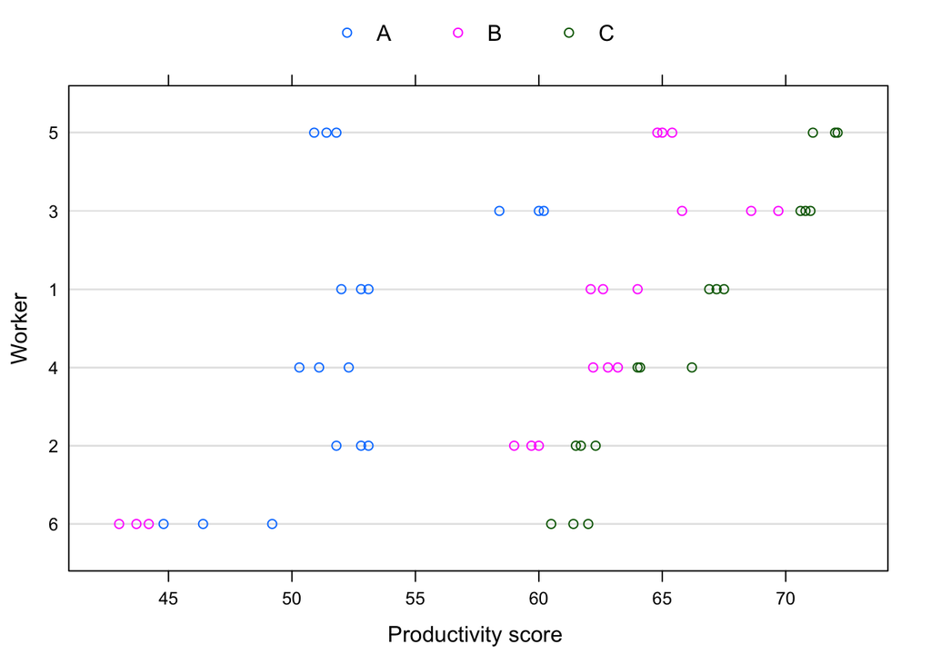

```r
plot(Machines)
```

# Different random term models

General model call is `lme(score ~ Machine, data = Machines, random = list(...))` with `...` replaced with below presented declarations of the random effects (or replacement of the whole term *random = …* with the simplified alternative)

## Worker = pdIdent(~1) or `random = ~ 1 | Worker`

Equal variances of the general mean (intercept) for all levels of random variable (Worker)

```r
fm1Machine <- lme(score ~ Machine, data = Machines, random = ~ 1 | Worker)
fm1Machine
```

```
## Linear mixed-effects model fit by REML
##   Data: Machines
##   Log-restricted-likelihood: -143.4391
##   Fixed: score ~ Machine
## (Intercept)    MachineB    MachineC
##   52.355556    7.966667   13.916667
##
## Random effects:
##  Formula: ~1 | Worker
##         (Intercept) Residual
## StdDev:    5.146552 3.161647
##
## Number of Observations: 54
## Number of Groups: 6
```

```r
ranef(fm1Machine)
```

```
##   (Intercept)
## 6 -8.70711058
## 2 -1.59425968
## 4 -0.06931564
## 1  1.21035769
## 3  6.21174760
## 5  2.94858062
```

## Worker = pdIdent(~1), Machine = pdIdent(~1) or `random = ~ 1 | Worker/Machine`

Equal variances of the general mean (intercept) for all levels of outer random variable (Worker) and combinations of both (Worker:Machine)

```r
fm2Machine <- update( fm1Machine, random = list(Worker = pdIdent(~1), Machine = pdIdent(~1)) )
#fm2Machine <- update( fm1Machine, random = ~ 1 | Worker/Machine )
fm2Machine
```

```
## Linear mixed-effects model fit by REML
##   Data: Machines
##   Log-restricted-likelihood: -107.8438
##   Fixed: score ~ Machine
## (Intercept)    MachineB    MachineC
##   52.355556    7.966667   13.916667
##
## Random effects:
##  Formula: ~1 | Worker
##         (Intercept)
## StdDev:     4.78105
##
##  Formula: ~1 | Machine %in% Worker
##         (Intercept)  Residual
## StdDev:    3.729532 0.9615771
##
## Number of Observations: 54
## Number of Groups:
##              Worker Machine %in% Worker
##                   6                  18
```

```r
ranef(fm2Machine)
```

```
## Level: Worker
##   (Intercept)
## 6 -7.51429458
## 2 -1.37585675
## 4 -0.05981986
## 1  1.04454677
## 3  5.36077966
## 5  2.54464477
##
## Level: Machine %in% Worker
##     (Intercept)
## 6/A   1.9162774
## 6/B  -8.9757070
## 6/C   2.4869652
## 2/A   1.5525655
## 2/B   0.6068543
## 2/C  -2.9966316
## 4/A  -1.0393716
## 4/B   2.4173660
## 4/C  -1.4143950
## 1/A  -0.7501469
## 1/B   1.4999936
## 1/C  -0.1142377
## 3/A   1.7776091
## 3/B   2.2993809
## 3/C  -0.8149440
## 5/A  -3.4569335
## 5/B   2.1521123
## 5/C   2.8532431
```

## Worker = pdSymm(~Machine-1)

Equivalent to `random = ~Machine-1|Worker` Different variances of the Machine effects for all levels of outer random variable (Worker) and combinations of both (Worker:Machine)

```r
  fm3Machine <- update(fm1Machine, random = pdSymm(~Machine-1))
  # same as fm3Machine2 <- update(fm1Machine, random = ~Machine-1|Worker)
  fm3Machine # == fm3Machine2
```

```
## Linear mixed-effects model fit by REML
##   Data: Machines
##   Log-restricted-likelihood: -104.1556
##   Fixed: score ~ Machine
## (Intercept)    MachineB    MachineC
##   52.355556    7.966667   13.916667
##
## Random effects:
##  Formula: ~Machine - 1 | Worker
##  Structure: General positive-definite
##          StdDev    Corr
## MachineA 4.0792807 MachnA MachnB
## MachineB 8.6252908 0.803
## MachineC 4.3894795 0.623  0.771
## Residual 0.9615766
##
## Number of Observations: 54
## Number of Groups: 6
```

```r
  fm3Machine$modelStruct$reStruct$Worker
```

```
## Positive definite matrix structure of class pdSymm representing
##          MachineA MachineB MachineC
## MachineA 17.99697 30.54709 12.05512
## MachineB 30.54709 80.45994 31.56299
## MachineC 12.05512 31.56299 20.83811
```

```r
  ranef(fm3Machine)
```

```
##     MachineA    MachineB   MachineC
## 6 -5.5916013 -16.5838056 -5.0300737
## 2  0.1838844  -0.8033247 -4.2822823
## 4 -1.0238706   2.3284558 -1.4146283
## 1  0.3119890   2.5532237  0.9302963
## 3  6.9692218   7.7793500  4.4735105
## 5 -0.8496233   4.7261008  5.3231775
```

## Worker = pdCompSymm(~Machine-1)

```r
  fm4Machine <- update(fm3Machine, random = pdCompSymm(~Machine-1))
  fm4Machine
```

```
## Linear mixed-effects model fit by REML
##   Data: Machines
##   Log-restricted-likelihood: -107.8438
##   Fixed: score ~ Machine
## (Intercept)    MachineB    MachineC
##   52.355556    7.966667   13.916667
##
## Random effects:
##  Formula: ~Machine - 1 | Worker
##  Structure: Compound Symmetry
##          StdDev    Corr
## MachineA 6.0636541
## MachineB 6.0636541 0.622
## MachineC 6.0636541 0.622 0.622
## Residual 0.9615766
##
## Number of Observations: 54
## Number of Groups: 6
```

```r
  fm4Machine$modelStruct$reStruct$Worker
```

```
## Positive definite matrix structure of class pdCompSymm representing
##          MachineA MachineB MachineC
## MachineA 39.76500 24.72173 24.72173
## MachineB 24.72173 39.76500 24.72173
## MachineC 24.72173 24.72173 39.76500
```

```r
  ranef(fm4Machine)
```

```
##     MachineA    MachineB   MachineC
## 6 -5.5980169 -16.4900024 -5.0273291
## 2  0.1767089  -0.7690024 -4.3724886
## 4 -1.0991915   2.3575464 -1.4742150
## 1  0.2943997   2.5445405  0.9303091
## 3  7.1383889   7.6601607  4.5458355
## 5 -0.9122891   4.6967573  5.3978881
```

## Worker = pdIdent(~Machine-1))

```r
  fm4Machine_ID <- update(fm3Machine, random = pdIdent(~Machine-1))
  fm4Machine_ID
```

```
## Linear mixed-effects model fit by REML
##   Data: Machines
##   Log-restricted-likelihood: -110.6278
##   Fixed: score ~ Machine
## (Intercept)    MachineB    MachineC
##   52.355556    7.966667   13.916667
##
## Random effects:
##  Formula: ~Machine - 1 | Worker
##  Structure: Multiple of an Identity
##         MachineA MachineB MachineC  Residual
## StdDev: 6.063654 6.063654 6.063654 0.9615766
##
## Number of Observations: 54
## Number of Groups: 6
```

```r
  fm4Machine_ID$modelStruct$reStruct$Worker
```

```
## Positive definite matrix structure of class pdIdent representing
##          MachineA MachineB MachineC
## MachineA   39.765    0.000    0.000
## MachineB    0.000   39.765    0.000
## MachineC    0.000    0.000   39.765
```

```r
  ranef(fm4Machine_ID)
```

```
##     MachineA    MachineB   MachineC
## 6 -5.5093728 -16.5501559 -4.9308887
## 2  0.2093562  -0.7492747 -4.4019889
## 4 -1.1128933   2.3910678 -1.4930400
## 1  0.2754686   2.5563490  0.9200653
## 3  7.1181097   7.6470094  4.4901388
## 5 -0.9806684   4.7050044  5.4157135
```

## Worker = pdIdent(~Worker-1)

```r
  fm4Machine_W <- update(fm3Machine, random = pdIdent(~Worker-1))
  fm4Machine_W
```

```
## Linear mixed-effects model fit by REML
##   Data: Machines
##   Log-restricted-likelihood: -143.4391
##   Fixed: score ~ Machine
## (Intercept)    MachineB    MachineC
##   52.355556    7.966667   13.916667
##
## Random effects:
##  Formula: ~Worker - 1 | Worker
##  Structure: Multiple of an Identity
##          Worker6  Worker2  Worker4  Worker1  Worker3  Worker5 Residual
## StdDev: 5.146552 5.146552 5.146552 5.146552 5.146552 5.146552 3.161647
##
## Number of Observations: 54
## Number of Groups: 6
```

```r
  fm4Machine_W$modelStruct$reStruct$Worker
```

```
## Positive definite matrix structure of class pdIdent representing
##          Worker6  Worker2  Worker4  Worker1  Worker3  Worker5
## Worker6 2.649755 0.000000 0.000000 0.000000 0.000000 0.000000
## Worker2 0.000000 2.649755 0.000000 0.000000 0.000000 0.000000
## Worker4 0.000000 0.000000 2.649755 0.000000 0.000000 0.000000
## Worker1 0.000000 0.000000 0.000000 2.649755 0.000000 0.000000
## Worker3 0.000000 0.000000 0.000000 0.000000 2.649755 0.000000
## Worker5 0.000000 0.000000 0.000000 0.000000 0.000000 2.649755
```

```r
  VarCorr(fm4Machine_W)
```

```
## Worker = pdIdent(Worker - 1)
##          Variance  StdDev
## Worker6  26.486993 5.146552
## Worker2  26.486993 5.146552
## Worker4  26.486993 5.146552
## Worker1  26.486993 5.146552
## Worker3  26.486993 5.146552
## Worker5  26.486993 5.146552
## Residual  9.996015 3.161647
```

```r
  ranef(fm4Machine_W)
```

```
##     Worker6  Worker2     Worker4  Worker1  Worker3  Worker5
## 6 -8.707111  0.00000  0.00000000 0.000000 0.000000 0.000000
## 2  0.000000 -1.59426  0.00000000 0.000000 0.000000 0.000000
## 4  0.000000  0.00000 -0.06931564 0.000000 0.000000 0.000000
## 1  0.000000  0.00000  0.00000000 1.210358 0.000000 0.000000
## 3  0.000000  0.00000  0.00000000 0.000000 6.211748 0.000000
## 5  0.000000  0.00000  0.00000000 0.000000 0.000000 2.948581
```

```r
  coef(fm4Machine_W)
```

```
##   (Intercept) MachineB MachineC   Worker6  Worker2     Worker4  Worker1
## 6    52.35556 7.966667 13.91667 -8.707111  0.00000  0.00000000 0.000000
## 2    52.35556 7.966667 13.91667  0.000000 -1.59426  0.00000000 0.000000
## 4    52.35556 7.966667 13.91667  0.000000  0.00000 -0.06931564 0.000000
## 1    52.35556 7.966667 13.91667  0.000000  0.00000  0.00000000 1.210358
## 3    52.35556 7.966667 13.91667  0.000000  0.00000  0.00000000 0.000000
## 5    52.35556 7.966667 13.91667  0.000000  0.00000  0.00000000 0.000000
##    Worker3  Worker5
## 6 0.000000 0.000000
## 2 0.000000 0.000000
## 4 0.000000 0.000000
## 1 0.000000 0.000000
## 3 6.211748 0.000000
## 5 0.000000 2.948581
```

## Worker = pdCompSymm(~Worker-1)

```r
  fm4Machine_WCS <- update(fm3Machine, random = pdCompSymm(~Worker-1))
  fm4Machine_WCS
```

```
## Linear mixed-effects model fit by REML
##   Data: Machines
##   Log-restricted-likelihood: -143.4391
##   Fixed: score ~ Machine
## (Intercept)    MachineB    MachineC
##   52.355556    7.966667   13.916667
##
## Random effects:
##  Formula: ~Worker - 1 | Worker
##  Structure: Compound Symmetry
##          StdDev   Corr
## Worker6  5.146552
## Worker2  5.146552 0
## Worker4  5.146552 0    0
## Worker1  5.146552 0    0 0
## Worker3  5.146552 0    0 0 0
## Worker5  5.146552 0    0 0 0 0
## Residual 3.161647
##
## Number of Observations: 54
## Number of Groups: 6
```

```r
  fm4Machine_WCS$modelStruct$reStruct$Worker
```

```
## Positive definite matrix structure of class pdCompSymm representing
##              Worker6      Worker2      Worker4      Worker1      Worker3
## Worker6 2.649755e+00 1.149404e-07 1.149404e-07 1.149404e-07 1.149404e-07
## Worker2 1.149404e-07 2.649755e+00 1.149404e-07 1.149404e-07 1.149404e-07
## Worker4 1.149404e-07 1.149404e-07 2.649755e+00 1.149404e-07 1.149404e-07
## Worker1 1.149404e-07 1.149404e-07 1.149404e-07 2.649755e+00 1.149404e-07
## Worker3 1.149404e-07 1.149404e-07 1.149404e-07 1.149404e-07 2.649755e+00
## Worker5 1.149404e-07 1.149404e-07 1.149404e-07 1.149404e-07 1.149404e-07
##              Worker5
## Worker6 1.149404e-07
## Worker2 1.149404e-07
## Worker4 1.149404e-07
## Worker1 1.149404e-07
## Worker3 1.149404e-07
## Worker5 2.649755e+00
```

```r
  VarCorr(fm4Machine_WCS)
```

```
## Worker = pdCompSymm(Worker - 1)
##          Variance  StdDev   Corr
## Worker6  26.486993 5.146552
## Worker2  26.486993 5.146552 0
## Worker4  26.486993 5.146552 0    0
## Worker1  26.486993 5.146552 0    0 0
## Worker3  26.486993 5.146552 0    0 0 0
## Worker5  26.486993 5.146552 0    0 0 0 0
## Residual  9.996015 3.161647
```

```r
  ranef(fm4Machine_WCS)
```

```
##         Worker6       Worker2       Worker4       Worker1       Worker3
## 6 -8.707111e+00 -3.776949e-07 -3.776949e-07 -3.776949e-07 -3.776949e-07
## 2 -6.915541e-08 -1.594260e+00 -6.915542e-08 -6.915540e-08 -6.915541e-08
## 4 -3.006757e-09 -3.006729e-09 -6.931564e-02 -3.006753e-09 -3.006753e-09
## 1  5.250260e-08  5.250264e-08  5.250259e-08  1.210358e+00  5.250260e-08
## 3  2.694517e-07  2.694517e-07  2.694517e-07  2.694517e-07  6.211748e+00
## 5  1.279028e-07  1.279028e-07  1.279028e-07  1.279028e-07  1.279028e-07
##         Worker5
## 6 -3.776949e-07
## 2 -6.915541e-08
## 4 -3.006757e-09
## 1  5.250259e-08
## 3  2.694517e-07
## 5  2.948581e+00
```

```r
  coef(fm4Machine_WCS)
```

```
##   (Intercept) MachineB MachineC       Worker6       Worker2       Worker4
## 6    52.35556 7.966667 13.91667 -8.707111e+00 -3.776949e-07 -3.776949e-07
## 2    52.35556 7.966667 13.91667 -6.915541e-08 -1.594260e+00 -6.915542e-08
## 4    52.35556 7.966667 13.91667 -3.006757e-09 -3.006729e-09 -6.931564e-02
## 1    52.35556 7.966667 13.91667  5.250260e-08  5.250264e-08  5.250259e-08
## 3    52.35556 7.966667 13.91667  2.694517e-07  2.694517e-07  2.694517e-07
## 5    52.35556 7.966667 13.91667  1.279028e-07  1.279028e-07  1.279028e-07
##         Worker1       Worker3       Worker5
## 6 -3.776949e-07 -3.776949e-07 -3.776949e-07
## 2 -6.915540e-08 -6.915541e-08 -6.915541e-08
## 4 -3.006753e-09 -3.006753e-09 -3.006757e-09
## 1  1.210358e+00  5.250260e-08  5.250259e-08
## 3  2.694517e-07  6.211748e+00  2.694517e-07
## 5  1.279028e-07  1.279028e-07  2.948581e+00
```

## Worker = pdDiag(~Worker-1)

```r
  fm4Machine_WDiag <- update(fm3Machine, random = pdDiag(~Worker-1))
  fm4Machine_WDiag
```

```
## Linear mixed-effects model fit by REML
##   Data: Machines
##   Log-restricted-likelihood: -140.4044
##   Fixed: score ~ Machine
## (Intercept)    MachineB    MachineC
##   52.972597    7.966667   13.916667
##
## Random effects:
##  Formula: ~Worker - 1 | Worker
##  Structure: Diagonal
##          Worker6  Worker2      Worker4      Worker1  Worker3  Worker5
## StdDev: 9.655951 2.132026 0.0004869744 0.0002866349 5.799888 2.320231
##         Residual
## StdDev: 3.149278
##
## Number of Observations: 54
## Number of Groups: 6
```

```r
  fm4Machine_WDiag$modelStruct$reStruct$Worker
```

```
## Positive definite matrix structure of class pdDiag representing
##          Worker6   Worker2      Worker4      Worker1  Worker3   Worker5
## Worker6 9.400868 0.0000000 0.000000e+00 0.000000e+00 0.000000 0.0000000
## Worker2 0.000000 0.4583139 0.000000e+00 0.000000e+00 0.000000 0.0000000
## Worker4 0.000000 0.0000000 2.391059e-08 0.000000e+00 0.000000 0.0000000
## Worker1 0.000000 0.0000000 0.000000e+00 8.283922e-09 0.000000 0.0000000
## Worker3 0.000000 0.0000000 0.000000e+00 0.000000e+00 3.391698 0.0000000
## Worker5 0.000000 0.0000000 0.000000e+00 0.000000e+00 0.000000 0.5428007
```

```r
  VarCorr(fm4Machine_WDiag)
```

```
## Worker = pdDiag(Worker - 1)
##          Variance     StdDev
## Worker6  9.323739e+01 9.6559507947
## Worker2  4.545537e+00 2.1320264598
## Worker4  2.371441e-07 0.0004869744
## Worker1  8.215956e-08 0.0002866349
## Worker3  3.363870e+01 5.7998883367
## Worker5  5.383473e+00 2.3202312402
## Residual 9.917955e+00 3.1492784496
```

```r
  ranef(fm4Machine_WDiag)
```

```
##     Worker6  Worker2       Worker4      Worker1  Worker3  Worker5
## 6 -9.576081  0.00000  0.000000e+00 0.000000e+00 0.000000 0.000000
## 2  0.000000 -1.83362  0.000000e+00 0.000000e+00 0.000000 0.000000
## 4  0.000000  0.00000 -1.483262e-07 0.000000e+00 0.000000 0.000000
## 1  0.000000  0.00000  0.000000e+00 4.801882e-08 0.000000 0.000000
## 3  0.000000  0.00000  0.000000e+00 0.000000e+00 5.669451 0.000000
## 5  0.000000  0.00000  0.000000e+00 0.000000e+00 0.000000 2.038003
```

```r
  coef(fm4Machine_WDiag)
```

```
##   (Intercept) MachineB MachineC   Worker6  Worker2       Worker4
## 6     52.9726 7.966667 13.91667 -9.576081  0.00000  0.000000e+00
## 2     52.9726 7.966667 13.91667  0.000000 -1.83362  0.000000e+00
## 4     52.9726 7.966667 13.91667  0.000000  0.00000 -1.483262e-07
## 1     52.9726 7.966667 13.91667  0.000000  0.00000  0.000000e+00
## 3     52.9726 7.966667 13.91667  0.000000  0.00000  0.000000e+00
## 5     52.9726 7.966667 13.91667  0.000000  0.00000  0.000000e+00
##        Worker1  Worker3  Worker5
## 6 0.000000e+00 0.000000 0.000000
## 2 0.000000e+00 0.000000 0.000000
## 4 0.000000e+00 0.000000 0.000000
## 1 4.801882e-08 0.000000 0.000000
## 3 0.000000e+00 5.669451 0.000000
## 5 0.000000e+00 0.000000 2.038003
```

## Comparison of models for Workers

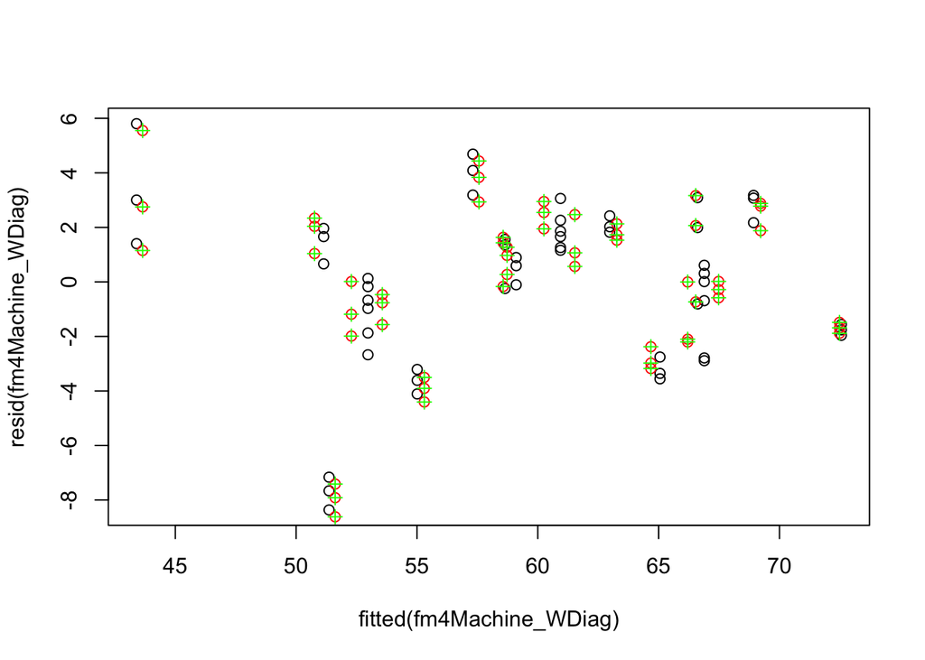

```r
  plot(resid(fm4Machine_WDiag)~fitted(fm4Machine_WDiag))
  points(resid(fm4Machine_W)~fitted(fm4Machine_W), col="red")
  points(resid(fm4Machine_WCS)~fitted(fm4Machine_WCS), col="green", pch=3)
```

```r
  anova(fm4Machine_W, fm4Machine_WCS, fm4Machine_WDiag)
```

```
##                  Model df      AIC      BIC    logLik   Test  L.Ratio
## fm4Machine_W         1  5 296.8782 306.5373 -143.4391
## fm4Machine_WCS       2  6 298.8782 310.4692 -143.4391 1 vs 2 0.000000
## fm4Machine_WDiag     3 10 300.8089 320.1271 -140.4044 2 vs 3 6.069345
##                  p-value
## fm4Machine_W
## fm4Machine_WCS     1.000
## fm4Machine_WDiag   0.194
```

```r
  fm4Machine_Blocked <- lme(score ~ Machine, data = Machines, random = list(Worker = pdBlocked(list( pdCompSymm(~Machine-1), pdDiag(~Worker-1)))))
  fm4Machine_Blocked
```

```
## Linear mixed-effects model fit by REML
##   Data: Machines
##   Log-restricted-likelihood: -104.6331
##   Fixed: score ~ Machine
## (Intercept)    MachineB    MachineC
##   53.569084    7.966667   13.916667
##
## Random effects:
##  Composite Structure: Blocked
##
##  Block 1: MachineA, MachineB, MachineC
##  Formula: ~Machine - 1 | Worker
##  Structure: Compound Symmetry
##          StdDev   Corr
## MachineA 3.045223
## MachineB 3.045223 -0.5
## MachineC 3.045223 -0.5 -0.5
##
##  Block 2: Worker6, Worker2, Worker4, Worker1, Worker3, Worker5
##  Formula: ~Worker - 1 | Worker
##  Structure: Diagonal
##          Worker6  Worker2 Worker4      Worker1  Worker3  Worker5  Residual
## StdDev: 10.28528 2.872951 1.28197 5.490482e-07 5.257771 1.856082 0.9606088
##
## Number of Observations: 54
## Number of Groups: 6
```

```r
  fm4Machine_Blocked$modelStruct$reStruct$Worker
```

```
## Positive definite matrix structure of class pdBlocked representing
##           MachineA  MachineB  MachineC  Worker6  Worker2  Worker4
## MachineA 10.049517 -5.024758 -5.024758   0.0000 0.000000 0.000000
## MachineB -5.024758 10.049517 -5.024758   0.0000 0.000000 0.000000
## MachineC -5.024758 -5.024758 10.049517   0.0000 0.000000 0.000000
## Worker6   0.000000  0.000000  0.000000 114.6407 0.000000 0.000000
## Worker2   0.000000  0.000000  0.000000   0.0000 8.944649 0.000000
## Worker4   0.000000  0.000000  0.000000   0.0000 0.000000 1.780996
## Worker1   0.000000  0.000000  0.000000   0.0000 0.000000 0.000000
## Worker3   0.000000  0.000000  0.000000   0.0000 0.000000 0.000000
## Worker5   0.000000  0.000000  0.000000   0.0000 0.000000 0.000000
##               Worker1  Worker3  Worker5
## MachineA 0.000000e+00  0.00000 0.000000
## MachineB 0.000000e+00  0.00000 0.000000
## MachineC 0.000000e+00  0.00000 0.000000
## Worker6  0.000000e+00  0.00000 0.000000
## Worker2  0.000000e+00  0.00000 0.000000
## Worker4  0.000000e+00  0.00000 0.000000
## Worker1  3.266839e-13  0.00000 0.000000
## Worker3  0.000000e+00 29.95782 0.000000
## Worker5  0.000000e+00  0.00000 3.733371
```

```r
  VarCorr(fm4Machine_Blocked)
```

```
## Worker = pdCompSymm(Machine - 1), pdDiag(Worker - 1)
##          Variance     StdDev
## MachineA 9.273385e+00 3.045223e+00
## MachineB 9.273385e+00 3.045223e+00
## MachineC 9.273385e+00 3.045223e+00
## Worker6  1.057869e+02 1.028528e+01
## Worker2  8.253847e+00 2.872951e+00
## Worker4  1.643448e+00 1.281970e+00
## Worker1  3.014539e-13 5.490482e-07
## Worker3  2.764416e+01 5.257771e+00
## Worker5  3.445040e+00 1.856082e+00
## Residual 9.227693e-01 9.606088e-01
```

```r
  ranef(fm4Machine_Blocked)
```

```
##     MachineA   MachineB   MachineC   Worker6   Worker2   Worker4
## 6  3.4405859 -7.4518852  4.0112992 -10.27579  0.000000  0.000000
## 2  1.8317179  0.8859645 -2.7176824   0.00000 -2.839368  0.000000
## 4 -1.0272840  2.4296081 -1.4023241   0.00000  0.000000 -1.210247
## 1 -0.9620596  1.2881815 -0.3261219   0.00000  0.000000  0.000000
## 3  0.6902913  1.2120864 -1.9023777   0.00000  0.000000  0.000000
## 5 -3.9732517  1.6360448  2.3372069   0.00000  0.000000  0.000000
##        Worker1  Worker3  Worker5
## 6 0.000000e+00 0.000000 0.000000
## 2 0.000000e+00 0.000000 0.000000
## 4 0.000000e+00 0.000000 0.000000
## 1 1.399016e-13 0.000000 0.000000
## 3 0.000000e+00 5.239262 0.000000
## 5 0.000000e+00 0.000000 1.804975
```

```r
  coef(fm4Machine_Blocked)
```

```
##   (Intercept)   MachineB MachineC   MachineA   Worker6   Worker2   Worker4
## 6    53.56908  0.5147815 17.92797  3.4405859 -10.27579  0.000000  0.000000
## 2    53.56908  8.8526311 11.19898  1.8317179   0.00000 -2.839368  0.000000
## 4    53.56908 10.3962747 12.51434 -1.0272840   0.00000  0.000000 -1.210247
## 1    53.56908  9.2548481 13.59054 -0.9620596   0.00000  0.000000  0.000000
## 3    53.56908  9.1787530 12.01429  0.6902913   0.00000  0.000000  0.000000
## 5    53.56908  9.6027115 16.25387 -3.9732517   0.00000  0.000000  0.000000
##        Worker1  Worker3  Worker5
## 6 0.000000e+00 0.000000 0.000000
## 2 0.000000e+00 0.000000 0.000000
## 4 0.000000e+00 0.000000 0.000000
## 1 1.399016e-13 0.000000 0.000000
## 3 0.000000e+00 5.239262 0.000000
## 5 0.000000e+00 0.000000 1.804975
```

```r
  fm4Machine_Blocked$coefficients$fixed
```

```
## (Intercept)    MachineB    MachineC
##   53.569084    7.966667   13.916667
```

```r
  fm4Machine_Blocked$coefficients$random
```

```
## $Worker
##     MachineA   MachineB   MachineC   Worker6   Worker2   Worker4
## 6  3.4405859 -7.4518852  4.0112992 -10.27579  0.000000  0.000000
## 2  1.8317179  0.8859645 -2.7176824   0.00000 -2.839368  0.000000
## 4 -1.0272840  2.4296081 -1.4023241   0.00000  0.000000 -1.210247
## 1 -0.9620596  1.2881815 -0.3261219   0.00000  0.000000  0.000000
## 3  0.6902913  1.2120864 -1.9023777   0.00000  0.000000  0.000000
## 5 -3.9732517  1.6360448  2.3372069   0.00000  0.000000  0.000000
##        Worker1  Worker3  Worker5
## 6 0.000000e+00 0.000000 0.000000
## 2 0.000000e+00 0.000000 0.000000
## 4 0.000000e+00 0.000000 0.000000
## 1 1.399016e-13 0.000000 0.000000
## 3 0.000000e+00 5.239262 0.000000
## 5 0.000000e+00 0.000000 1.804975
```